# week_14_sklearn_logistic

## CMPINF 2100 Week 14

### Introduction to fitting logistic regression models using scikit-learn

You will learn how to use the ARRAY interface for statsmodels as a preliminary for learning how to work with sklearn's predictive model functions.

## Import Modules

```python
import numpy as np
import pandas as pd
import matplotlib.pyplot as plt

import seaborn as sns
```

## Read data

We will use a simpler example compared to the WEEK 13 binary classification example.

Lets go back to WEEK 12 example which involved a SINGLE continuous input and a BINARY OUTCOME.

```python
df = pd.read_csv("../week_12/week_11_intro_binary_classification.csv")
```

```python
df.info()
```

```
<class 'pandas.core.frame.DataFrame'>
RangeIndex: 115 entries, 0 to 114
Data columns (total 2 columns):
 #   Column  Non-Null Count  Dtype
---  ------  --------------  -----
 0   x       115 non-null    float64
 1   y       115 non-null    int64
dtypes: float64(1), int64(1)
memory usage: 1.9 KB
```

```python
df.nunique()
```

```
x    115
y      2
dtype: int64
```

```python
df.y.value_counts()
```

```
y
0    67
1    48
Name: count, dtype: int64
```

## Fit logistic regression models

### Formula interface

```python
import statsmodels.formula.api as smf
```

```python
fit_stats_formula = smf.logit(formula="y ~ x", data=df).fit()
```

```
Optimization terminated successfully.
         Current function value: 0.560099
         Iterations 6
```

```python
fit_stats_formula.params
```

```
Intercept   -0.449518
x            1.183814
dtype: float64
```

```python
fit_stats_formula.bse
```

```
Intercept    0.218009
x            0.267133
dtype: float64
```

```python
fit_stats_formula.conf_int()
```

|  | 0 | 1 |
| --- | --- | --- |
| Intercept | -0.876808 | -0.022228 |
| x | 0.660243 | 1.707385 |

```python
fit_stats_formula.pvalues
```

```
Intercept    0.039215
x            0.000009
dtype: float64
```

We also know how to PREDICT A NEW DATA SET to support visualization.

```python
input_grid = pd.DataFrame({"x": np.linspace(df.x.min()-.02, df.x.max()+.02, num=101)})
```

```python
dfviz = input_grid.copy()
```

```python
dfviz["pred_probability_statsformula"] = fit_stats_formula.predict(input_grid)
```

```python
dfviz
```

|  | x | pred_probability_statsformula |
| --- | --- | --- |
| 0 | -2.079272 | 0.051613 |
| 1 | -2.033891 | 0.054307 |
| 2 | -1.988509 | 0.057133 |
| 3 | -1.943128 | 0.060097 |
| 4 | -1.897747 | 0.063204 |
| ... | ... | ... |
| 96 | 2.277334 | 0.904341 |
| 97 | 2.322715 | 0.908889 |
| 98 | 2.368097 | 0.913241 |
| 99 | 2.413478 | 0.917404 |
| 100 | 2.458859 | 0.921385 |

101 rows × 2 columns

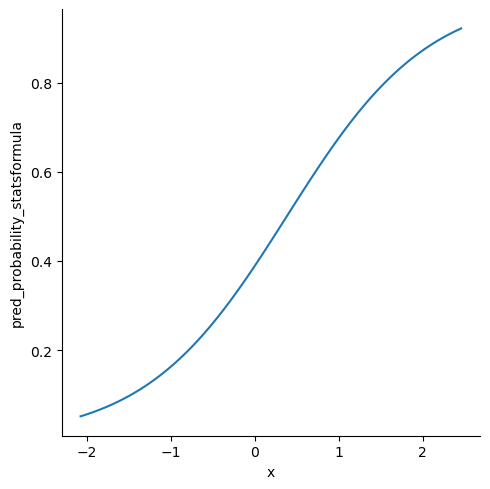

```python
sns.relplot(data=dfviz, x="x", y="pred_probability_statsformula", kind="line")

plt.show()
```

We know how to CLASSIFY predictions by comparing the PREDICTED PROBABILITY to a THRESHOLD.

```python
dfviz["pred_class_statsformula"] = np.where(dfviz.pred_probability_statsformula > 0.5, 1, 0)
```

```python
dfviz.pred_class_statsformula.value_counts()
```

```
pred_class_statsformula
0    55
1    46
Name: count, dtype: int64
```

## Array interface

There is an alternative INTERFACE to statsmodels. This alternative does **NOT** rely on the formula!!

Instead, we must provide arrays for the input FEATURES and for the OUTPUT.

This alternative interface is from the statsmodels.api module.

```python
import statsmodels.api as sm
```

However, I never import statsmodels.api ALONE. It needs HELPERS from the patsy module. We need a function for GENERATING the FEATURE and OUTPUT arrays!!!

```python
from patsy import dmatrices
```

```python
from patsy import dmatrix
```

The dmatrices function USES a FORMULA to specify the FEATURES from the INPUT!!!

The dmatrices function generates the OUTPUT array and the FEATURE array based on the provided FORMULA!!!

Historically, the FEATURE array was called the **DESIGN MATRIX** and thats what the d in dmatrices stands for.

The dmatrices function RETURNS 2 objects.

`<output array>, <feature array> = dmatrices(<formula>, data= <data>)`

```python
yobs_mat, Xdesign_mat = dmatrices("y ~ x", data=df)
```

```python
type(yobs_mat)
```

```
patsy.design_info.DesignMatrix
```

```python
type(Xdesign_mat)
```

```
patsy.design_info.DesignMatrix
```

```python
yobs_mat.ndim
```

```
2
```

```python
Xdesign_mat.ndim
```

```
2
```

```python
yobs_mat.shape
```

```
(115, 1)
```

```python
Xdesign_mat.shape
```

```
(115, 2)
```

The output array has 1 column but 2 dimensions. But it is typically better to work with a 1D output array and so we must convert the 2D array to a 1D array using the .ravel().

```python
yobs_mat[:5, :]
```

```
array([[1.],
       [1.],
       [0.],
       [0.],
       [1.]])
```

```python
yobs_mat.ravel().shape
```

```
(115,)
```

```python
Xdesign_mat[:5, :]
```

```
array([[ 1.        , -0.45742915],
       [ 1.        ,  0.42594754],
       [ 1.        , -0.7846951 ],
       [ 1.        , -1.92520922],
       [ 1.        ,  2.25261708]])
```

The reason why the FEATURE array has 2 cols is because there are 2 coefficients estimated in this model!

```python
fit_stats_formula.params
```

```
Intercept   -0.449518
x            1.183814
dtype: float64
```

The number of cols in the DESIGN MATRIX or FEATURE ARRAY is equal to the NUMBER OF REGRESSION COEFFICIENTS that must be estimated!!!

Look athe zeroth col of the DESIGN MATRIX.

```python
Xdesign_mat[:10, 0]
```

```
array([1., 1., 1., 1., 1., 1., 1., 1., 1., 1.])
```

```python
np.unique(Xdesign_mat[:, 0])
```

```
array([1.])
```

The ZEROTH col of the DESIGN MATRIX or FEATURE ARRAY is special.

The ZEROTH col ONLY contains the value 1.

The ZEROTH col is referred to as the BIAS column or the INTERCEPT column.

We typically wrote the formula for the AVERAGE OUTPUT as: $$ \mu_n = \beta_0 + \beta_1 \times x_n $$ You can think of the INTERCEPT or BIAS column as a special constant FEATURE equal to 1 that multiplies the INTERCEPT. $$ \mu_n = \beta_0 \times 1 + \beta_1 \times x_n $$

```python
df
```

|  | x | y |
| --- | --- | --- |
| 0 | -0.457429 | 1 |
| 1 | 0.425948 | 1 |
| 2 | -0.784695 | 0 |
| 3 | -1.925209 | 0 |
| 4 | 2.252617 | 1 |
| ... | ... | ... |
| 110 | -0.791672 | 0 |
| 111 | 0.452238 | 1 |
| 112 | 0.535510 | 1 |
| 113 | -0.532739 | 0 |
| 114 | 0.317661 | 0 |

115 rows × 2 columns

```python
Xdesign_mat[:5, ]
```

```
array([[ 1.        , -0.45742915],
       [ 1.        ,  0.42594754],
       [ 1.        , -0.7846951 ],
       [ 1.        , -1.92520922],
       [ 1.        ,  2.25261708]])
```

```python
Xdesign_mat[-5:, ]
```

```
array([[ 1.        , -0.79167206],
       [ 1.        ,  0.45223789],
       [ 1.        ,  0.53551007],
       [ 1.        , -0.53273884],
       [ 1.        ,  0.3176613 ]])
```

The `dmatrices()` GENERATES THE FEATURE value from the INPUTS as specified by the formula!!!

So if we wanted a more complicated set of FEATURES `dmatrices()` would create for us!!!

For example, lets create QUADRATIC feature from the input `x`.

```python
y2, X2 = dmatrices("y ~ x + np.power(x, 2)", data=df)
```

```python
X2[:5, ]
```

```
array([[ 1.        , -0.45742915,  0.20924143],
       [ 1.        ,  0.42594754,  0.18143131],
       [ 1.        , -0.7846951 ,  0.61574641],
       [ 1.        , -1.92520922,  3.70643052],
       [ 1.        ,  2.25261708,  5.07428369]])
```

```python
df.x**2
```

```
0      0.209241
1      0.181431
2      0.615746
3      3.706431
4      5.074284
         ...
110    0.626745
111    0.204519
112    0.286771
113    0.283811
114    0.100909
Name: x, Length: 115, dtype: float64
```

The sm module has FUNCTIONS to fit the modesl just like smf. BUT the SYNTAX is different.

The sm module names the functions with a capital letter to distinguish from smf.

And you DO NOT use the formula. Instead, you provide the OUTPUT ARRAY and the FEATURE ARRAY.

The syntax for logistic regression looks like:

`sm.logit(<output array>, <feature array>).fit()`

```python
fit_stats_array = sm.Logit(yobs_mat.ravel(), Xdesign_mat).fit()
```

```
Optimization terminated successfully.
         Current function value: 0.560099
         Iterations 6
```

The array interface has the SAME attributes and methods as the formula interface!!

```python
fit_stats_array.params
```

```
array([-0.44951804,  1.1838136 ])
```

```python
fit_stats_array.bse
```

```
array([0.218009  , 0.26713298])
```

```python
fit_stats_array.conf_int()
```

```
array([[-0.87680783, -0.02222826],
       [ 0.66024258,  1.70738463]])
```

```python
fit_stats_array.pvalues
```

```
array([3.92149476e-02, 9.35573925e-06])
```

```python
fit_stats_formula.pvalues
```

```
Intercept    0.039215
x            0.000009
dtype: float64
```

```python
fit_stats_formula.conf_int()
```

|  | 0 | 1 |
| --- | --- | --- |
| Intercept | -0.876808 | -0.022228 |
| x | 0.660243 | 1.707385 |

The formula interface returns Pandas objects while the array interface returns NumPy objects.

To make predictions, we MUST create the FEATURE array on the NEW data set!

```python
input_grid
```

|  | x |
| --- | --- |
| 0 | -2.079272 |
| 1 | -2.033891 |
| 2 | -1.988509 |
| 3 | -1.943128 |
| 4 | -1.897747 |
| ... | ... |
| 96 | 2.277334 |
| 97 | 2.322715 |
| 98 | 2.368097 |
| 99 | 2.413478 |
| 100 | 2.458859 |

101 rows × 1 columns

We must create the FEATURE array for the input_grid in order to MAKE PREDICTIONS!

```python
ygrid, Xgrid = dmatrices("y ~ x", data=input_grid)
```

[output not shown]

[output cut: 53 more lines]

[output not shown]

The dmatrices() function creates the arrays when the OUTPUT is known or observed!!

The dmatrix() function is used when you ONLY have the INPUTS and the NOT the OUPUT!!

You should use dmatrix() when you need to create the VISUALIZATION grid to visualize PREDICTIONS!!!

```python
Xgrid = dmatrix(" ~ x", data=input_grid)
```

```python
Xgrid.shape
```

```
(101, 2)
```

```python
input_grid.shape
```

```
(101, 1)
```

```python
Xdesign_mat.shape
```

```
(115, 2)
```

```python
Xgrid[:5, ]
```

```
array([[ 1.        , -2.0792719 ],
       [ 1.        , -2.03389058],
       [ 1.        , -1.98850927],
       [ 1.        , -1.94312796],
       [ 1.        , -1.89774665]])
```

```python
input_grid
```

|  | x |
| --- | --- |
| 0 | -2.079272 |
| 1 | -2.033891 |
| 2 | -1.988509 |
| 3 | -1.943128 |
| 4 | -1.897747 |
| ... | ... |
| 96 | 2.277334 |
| 97 | 2.322715 |
| 98 | 2.368097 |
| 99 | 2.413478 |
| 100 | 2.458859 |

101 rows × 1 columns

Lets now add a column to dfviz for the predicted event probability from the ARRAY interface.

```python
dfviz["pred_probability_statsarray"] = fit_stats_array.predict(Xgrid)
```

```python
dfviz
```

|  | x | pred_probability_statsformula | pred_class_statsformula | pred_probability_statsarray |
| --- | --- | --- | --- | --- |
| 0 | -2.079272 | 0.051613 | 0 | 0.051613 |
| 1 | -2.033891 | 0.054307 | 0 | 0.054307 |
| 2 | -1.988509 | 0.057133 | 0 | 0.057133 |
| 3 | -1.943128 | 0.060097 | 0 | 0.060097 |
| 4 | -1.897747 | 0.063204 | 0 | 0.063204 |
| ... | ... | ... | ... | ... |
| 96 | 2.277334 | 0.904341 | 1 | 0.904341 |
| 97 | 2.322715 | 0.908889 | 1 | 0.908889 |
| 98 | 2.368097 | 0.913241 | 1 | 0.913241 |
| 99 | 2.413478 | 0.917404 | 1 | 0.917404 |
| 100 | 2.458859 | 0.921385 | 1 | 0.921385 |

101 rows × 4 columns

## Formula vs Array Interface

I never use the statsmodels array interface. The formula interface is FASTER to work with. You do NOT need to create the array objects for training or for making predictions!!!

Plus, you get to use the nice NAMES for everything. The regression coefficients are automatically named consistent with the features they multiply when you use the formula interface!!!

HOWEVER...we introducted the array interface here...because scikit-learn DOES NOT work with formulas!!! Scikit-learn has its own set of PREDICTIVE MODEL function! Scikit-learn can fit linear models for regressino and logistic regression models for classification but you must provide the output and feature arrays to scikit-learn!!

## Scikit-learn

The logistic regression function from scikit-learn is imported below.

```python
from sklearn.linear_model import LogisticRegression
```

If you were working with a linear regression you would instead import

```python
from sklearn.linear_model import LinearRegression
```

Scikit-learn PREDICTIVE MODEL functions follow the SAME workflow as the PREPROCESSING functions we worked with earlier in the semester!!!

The object must be INITIALIZED and then the object is FIT.

Once the model is FIT then you can PREDICT or MEASURE PERFORMANCE.

## Default and conventional usage

Remember when the scikit-lrarn object is INITIALIZED this is where we set the ASSUMPTIONS of rht model

Lets first use the DEFAULT assumptions.

We will also use the conventional or typical usage for the FEATURES.

The conventional approach when fitting predicted models with scikit-learn is to REMOVE the BIAS or INTERCEPT column of 1s!!!!

```python
Xdesign_mat[:5, ]
```

```
array([[ 1.        , -0.45742915],
       [ 1.        ,  0.42594754],
       [ 1.        , -0.7846951 ],
       [ 1.        , -1.92520922],
       [ 1.        ,  2.25261708]])
```

We can remove the INTERCEPT or BIAS column by including `'- 1'` in the formula definition

```python
"y ~ x"
```

```
'y ~ x'
```

```python
"y ~ x - 1"
```

```
'y ~ x - 1'
```

Use the `dmatrices()` to create the arrays for the default and conventional sklearn formulation.

```python
y_sk_default, X_sk_default = dmatrices("y ~ x - 1", data=df)
```

```python
X_sk_default.shape
```

```
(115, 1)
```

```python
y_sk_default.shape
```

```
(115, 1)
```

```python
y_sk_default.ravel()
```

```
array([1., 1., 0., 0., 1., 1., 0., 1., 1., 0., 1., 0., 1., 1., 1., 0., 1.,
       1., 0., 1., 0., 0., 0., 0., 0., 1., 0., 1., 0., 0., 1., 0., 0., 1.,
       0., 0., 0., 0., 0., 0., 0., 0., 1., 0., 1., 0., 1., 0., 1., 0., 0.,
       0., 1., 1., 0., 0., 1., 0., 0., 0., 0., 1., 1., 1., 1., 0., 0., 0.,
       0., 0., 1., 1., 0., 0., 0., 0., 1., 1., 0., 1., 0., 1., 1., 0., 0.,
       1., 1., 1., 0., 0., 1., 0., 0., 1., 0., 0., 0., 1., 0., 1., 1., 1.,
       0., 0., 1., 0., 1., 0., 0., 0., 0., 1., 1., 0., 0.])
```

Lets now INITIALIZE and then FIT the sklearn logistic regression model.

The syntax is VERY DIFFERENT from `statsmodels`.

The data are provided in the `.fit()` call RATHER than in the INITIALIZATION step as with `statsmodels.`

```python
sk_default_typical = LogisticRegression().fit(X_sk_default, y_sk_default.ravel())
```

Scikit-learn logistic regression models have their OWN set of attributes and methods which are DIFFERENT from `statsmodels.`

```python
dir(sk_default_typical)
```

```
['C',
 '__annotations__',
 '__class__',
 '__delattr__',
 '__dict__',
 '__dir__',
 '__doc__',
 '__eq__',
 '__format__',
 '__ge__',
 '__getattribute__',
 '__getstate__',
 '__gt__',
 '__hash__',
 '__init__',
 '__init_subclass__',
 '__le__',
 '__lt__',
 '__module__',
 '__ne__',
 '__new__',
 '__reduce__',
 '__reduce_ex__',
 '__repr__',
 '__setattr__',
 '__setstate__',
 '__sizeof__',
 '__sklearn_clone__',
 '__str__',
 '__subclasshook__',
 '__weakref__',
 '_build_request_for_signature',
 '_check_feature_names',
 '_check_n_features',
 '_estimator_type',
 '_get_default_requests',
 '_get_metadata_request',
 '_get_param_names',
 '_get_tags',
 '_more_tags',
```

[output cut: 24 more lines]

```
 'n_jobs',
 'penalty',
 'predict',
 'predict_log_proba',
 'predict_proba',
 'random_state',
 'score',
 'set_fit_request',
 'set_params',
 'set_score_request',
 'solver',
 'sparsify',
 'tol',
 'verbose',
 'warm_start']
```

The sciki-learn logistic regression model does **NOT** provide whether the features are statistically significant!!!

The coefficient estimates are avialable in the .coef_ attribute.

```python
fit_stats_formula.params
```

```
Intercept   -0.449518
x            1.183814
dtype: float64
```

```python
sk_default_typical.coef_
```

```
array([[1.10749129]])
```

The typical usage of sklearn is to HOUSE or CONTAIN the INTERCEPT in its own attribute!!!

```python
sk_default_typical.intercept_
```

```
array([-0.43772033])
```

## Do NOT fit the intercept

Lets change the ASSUMPTIONS and FEATURE array so that sklearn estimates the INTERCEPT as if its a regular coefficient.

We are essentially TRICKING sklearn.

We are doing this so that we can have an apples-to-apples comparison with statsmodels.

BUT you should also do this when you have CATEGORICAL INPUTS!!! Next week, we will wrap up the semester by discussing just why this is the case!!!

Heres how we can force the INTERCEPT to be estimated as if its a regular coefficient.

You NEED the INTERCEPT or BIAS column in the FEATURE array!!!

```python
Xdesign_mat[:5, ]
```

```
array([[ 1.        , -0.45742915],
       [ 1.        ,  0.42594754],
       [ 1.        , -0.7846951 ],
       [ 1.        , -1.92520922],
       [ 1.        ,  2.25261708]])
```

The next piece is you MUST set the `fit_intercept=False` when you INITIALIZE the object!!!

Lets use all other settings at their default values.

```python
sk_default = LogisticRegression(fit_intercept=False).fit(Xdesign_mat, yobs_mat.ravel())
```

The INTERCEPT attribute is now set to ZERO!!!

```python
sk_default.intercept_
```

```
array([0.])
```

The INTERCEPT is now contained with the SLOPE in the .coef_ attribute.

```python
sk_default.coef_
```

```
array([[-0.41847455,  1.10362554]])
```

```python
sk_default.coef_.shape
```

```
(1, 2)
```

```python
sk_default.coef_.ravel()
```

```
array([-0.41847455,  1.10362554])
```

This allows us to directly compare the SKLEARN coefficient estimates with the statsmodels estimates.

```python
fit_compare = pd.DataFrame({"statsmodels_formula": fit_stats_formula.params,
                           "statsmodels_array": pd.Series(fit_stats_array.params, index=fit_stats_formula.params.index),
                           "sklearn_default": pd.Series(sk_default.coef_.ravel(), index=fit_stats_formula.params.index)})
```

```python
fit_compare
```

|  | statsmodels_formula | statsmodels_array | sklearn_default |
| --- | --- | --- | --- |
| Intercept | -0.449518 | -0.449518 | -0.418475 |
| x | 1.183814 | 1.183814 | 1.103626 |

The sklearn estimates are **DIFFERENT** statsmodels!!

SKLEARN is NOT more correct than statsmodels.

STATSMODELS is NOT more correct than SKLEARN.

They are solving different problems by default!

We will discuss the differences next week.

For now, I want you to know how to force sklearn to behave like statsmodels!!!

The reason they are different is because SKLEARN is trying to PREVENT extreme coefficients estimates. It does so by using something called the PENALTY!!!

### Turn off the penalty to match statsmodels

Please note, you DO NOT need to do this with `LinearRegression()` function in sklearn. This is something specific to `LogisticRegression` in SKLEARN.

```python
sk_default.penalty
```

```
'l2'
```

We want to FORCE the penalty to be None. A NONE penalty means the coefficients are estimated in order to MINIMIZE a LOSS!!!!

Think of it as finding the coefficients that MINIMIZE the ERROR!!!

That's why I feel SKLEARN is VERY DANGEROUS when you use the DEFAULTS because it is EASY to forget what the DEFAULTS are!!!

I always recommend SPECIFYING the penalty argument and the solver argument so you KNOW exactly how the coefficients were estimated!!!

We will therefore force SKLEARN to MINIMIZE the LOSS JUST LIKE statsmodels!!! And we will have the INTERCEPT estimates as if its a regular coefficient.

```python
sk_min_loss = LogisticRegression(penalty=None, solver="lbfgs", fit_intercept=False).fit(Xdesign_mat, yobs_mat.ravel())
```

```python
sk_min_loss.coef_
```

```
array([[-0.44951919,  1.18381652]])
```

```python
sk_min_loss.penalty
```

Lets compare the estimated coefficients with statsmodels!!

```python
fit_compare["sklearn_none"] = pd.Series(sk_min_loss.coef_.ravel(), index=fit_stats_formula.params.index)
```

```python
fit_compare
```

|  | statsmodels_formula | statsmodels_array | sklearn_default | sklearn_none |
| --- | --- | --- | --- | --- |
| Intercept | -0.449518 | -0.449518 | -0.418475 | -0.449519 |
| x | 1.183814 | 1.183814 | 1.103626 | 1.183817 |

The estimates are NOT perfectly identical. But, they match down to 4-5 decimal points!!!

We have therefore converted sklearn to behave very very similary to statsmodels!!

## Why use sklearn?

### Downsides to sklearn

SKLEARN does NOT provide standard errors!! It only provides coefficient estimates!!!

We therefore CANNOT identify statistically significant coefficients and thus features!!!

We cannot identify the CONFIDENCE INTERVAL on trends from sklearn!!!

### Upsides to sklearn

SKLEARN is focused on calculating PERFORMANCE metrics!!!

It has a dedicated method, `.score()` for **SCORING** or GRADING or MEASURING the performance!!!

Lets calculate the training set Accuracy for statsmodels.

```python
df_copy = df.copy()
```

```python
df_copy["pred_probability"] = fit_stats_formula.predict(df)
```

```python
df_copy["pred_class"] = np.where(df_copy.pred_probability > 0.5, 1, 0)
```

```python
np.mean(df_copy.pred_class == df_copy.y)
```

```
0.6782608695652174
```

The `.score()` for LogisticRegression calculates the ACCURACY BY DEFAULT!!!!

It assumes a DEFAULT threshold of 0.5!!!

```python
sk_min_loss.score(Xdesign_mat, yobs_mat.ravel())
```

```
0.6782608695652174
```

## Predictions with sklearn

The `.predict()` method returns the CLASSIFICATION assuming a 0.5 threshold!

The `.predict()` methods REQUIRES the FEATURE ARRAY!!!

```python
Xgrid[:5, ]
```

```
array([[ 1.        , -2.0792719 ],
       [ 1.        , -2.03389058],
       [ 1.        , -1.98850927],
       [ 1.        , -1.94312796],
       [ 1.        , -1.89774665]])
```

```python
dfviz["pred_class_sklearn_none"] = sk_min_loss.predict(Xgrid)
```

```python
dfviz
```

|  | x | pred_probability_statsformula | pred_class_statsformula | pred_probability_statsarray | pred_class_sklearn_none |
| --- | --- | --- | --- | --- | --- |
| 0 | -2.079272 | 0.051613 | 0 | 0.051613 | 0.0 |
| 1 | -2.033891 | 0.054307 | 0 | 0.054307 | 0.0 |
| 2 | -1.988509 | 0.057133 | 0 | 0.057133 | 0.0 |
| 3 | -1.943128 | 0.060097 | 0 | 0.060097 | 0.0 |
| 4 | -1.897747 | 0.063204 | 0 | 0.063204 | 0.0 |
| ... | ... | ... | ... | ... | ... |
| 96 | 2.277334 | 0.904341 | 1 | 0.904341 | 1.0 |
| 97 | 2.322715 | 0.908889 | 1 | 0.908889 | 1.0 |
| 98 | 2.368097 | 0.913241 | 1 | 0.913241 | 1.0 |
| 99 | 2.413478 | 0.917404 | 1 | 0.917404 | 1.0 |
| 100 | 2.458859 | 0.921385 | 1 | 0.921385 | 1.0 |

101 rows × 5 columns

```python
dfviz.pred_class_sklearn_none.value_counts()
```

```
pred_class_sklearn_none
0.0    55
1.0    46
Name: count, dtype: int64
```

```python
pred_grid_sk = sk_min_loss.predict_proba(Xgrid)
```

```python
pred_grid_sk[:5, ]
```

```
array([[0.94838732, 0.05161268],
       [0.94569339, 0.05430661],
       [0.94286732, 0.05713268],
       [0.93990353, 0.06009647],
       [0.9367963 , 0.0632037 ]])
```

The CLASS orderings are provided by the `.classes_` attribute.

```python
sk_min_loss.classes_
```

```
array([0., 1.])
```

We need to provide a conditional test to find out which column is the EVENT PROBABILITY.

```python
pred_grid_sk[:, sk_min_loss.classes_ == 1].ravel()
```

```
array([0.05161268, 0.05430661, 0.05713268, 0.06009647, 0.0632037 ,
       0.06646023, 0.06987203, 0.0734452 , 0.07718594, 0.08110053,
       0.08519532, 0.08947672, 0.09395119, 0.09862517, 0.10350512,
       0.10859743, 0.11390845, 0.1194444 , 0.12521138, 0.13121531,
       0.13746189, 0.14395656, 0.15070448, 0.15771043, 0.16497881,
       0.17251355, 0.18031811, 0.18839536, 0.19674757, 0.20537637,
       0.21428265, 0.22346654, 0.23292736, 0.24266354, 0.25267264,
       0.26295124, 0.27349495, 0.28429836, 0.29535502, 0.30665745,
       0.31819708, 0.32996429, 0.34194842, 0.35413776, 0.36651959,
       0.37908024, 0.39180511, 0.40467874, 0.41768487, 0.43080651,
       0.44402605, 0.45732531, 0.47068567, 0.48408818, 0.49751361,
       0.51094263, 0.52435587, 0.53773407, 0.55105815, 0.56430935,
       0.57746932, 0.59052023, 0.60344485, 0.61622665, 0.62884985,
       0.64129954, 0.65356168, 0.66562321, 0.67747204, 0.68909711,
       0.70048841, 0.71163701, 0.72253499, 0.73317554, 0.74355286,
       0.75366219, 0.76349976, 0.77306276, 0.78234931, 0.79135841,
       0.80008988, 0.80854435, 0.81672318, 0.82462839, 0.83226266,
       0.83962923, 0.84673185, 0.85357477, 0.86016263, 0.86650045,
       0.87259357, 0.8784476 , 0.88406839, 0.88946197, 0.89463453,
       0.89959236, 0.90434185, 0.90888944, 0.91324157, 0.91740471,
       0.92138527])
```

```python
dfviz["pred_probability_sklearn_none"] = pd.Series(pred_grid_sk[:, sk_min_loss.classes_ == 1].ravel(), index=dfviz.index)
```

```python
dfviz
```

|  | x | pred_probability_statsformula | pred_class_statsformula | pred_probability_statsarray | pred_class_sklearn_none | pred_probability_sklearn_none |
| --- | --- | --- | --- | --- | --- | --- |
| 0 | -2.079272 | 0.051613 | 0 | 0.051613 | 0.0 | 0.051613 |
| 1 | -2.033891 | 0.054307 | 0 | 0.054307 | 0.0 | 0.054307 |
| 2 | -1.988509 | 0.057133 | 0 | 0.057133 | 0.0 | 0.057133 |
| 3 | -1.943128 | 0.060097 | 0 | 0.060097 | 0.0 | 0.060096 |
| 4 | -1.897747 | 0.063204 | 0 | 0.063204 | 0.0 | 0.063204 |
| ... | ... | ... | ... | ... | ... | ... |
| 96 | 2.277334 | 0.904341 | 1 | 0.904341 | 1.0 | 0.904342 |
| 97 | 2.322715 | 0.908889 | 1 | 0.908889 | 1.0 | 0.908889 |
| 98 | 2.368097 | 0.913241 | 1 | 0.913241 | 1.0 | 0.913242 |
| 99 | 2.413478 | 0.917404 | 1 | 0.917404 | 1.0 | 0.917405 |
| 100 | 2.458859 | 0.921385 | 1 | 0.921385 | 1.0 | 0.921385 |

101 rows × 6 columns

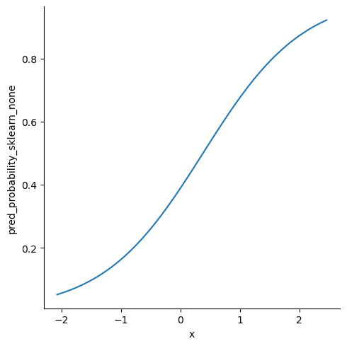

```python
sns.relplot(data=dfviz, x="x", y="pred_probability_sklearn_none", kind="line")

plt.show()
```